# question4

June 26, 2019

本文基于caICB对肿瘤组织HiC数据进行标准化，可以很好地降低CNV引起的bias。之后重新进行TAD和compartment分析

#### caICB normalization

1. **将raw matrix转换成hicapp要求的格式:**

`python /lustre/user/liclab/pengt/projects/lung/hic/5534N/resolution_40k/pair.py`

2. **用hicapp进行标准化:**

`/lustre/user/liclab/pengt/projects/tools/hicapp/hicapp_caICB -s 5534N.40k.pair -r 40000 -c`  
`/lustre/user/liclab/pengt/projects/lung/hic/MCF10A/chrom_hg19.sizes &`

3. **进行相关计算，提取得到最终标准化后的结果:**

`awk 'NR==FNR {a[$1]=$2} NR>FNR {B=a[$1]*a[$2]; if (B>0) print $0"\t"$3/B}' 5534N.40k.bychrom.caicb 5534N.40k.pair >`  
`5534N.40k.pair.norm`

#### TAD calling

1. **将normalized matrix 转换成insulation score 要求的格式:**

`Rscript /lustre/user/liclab/pengt/projects/lung/hic/caICB/5534N/TAD/pre_tadcalling.R`

2. **运行insulation score:**

`bash /lustre/user/liclab/pengt/projects/lung/hic/caICB/5534N/TAD/work.sh`

3. **合并所有boundary文件:**

`python /lustre/user/liclab/pengt/projects/lung/hic/caICB/5534N/TAD/TAD_boundary/pre.py`

4. **将boundary转换为TAD区域:**

`Rscript /lustre/user/liclab/pengt/projects/lung/hic/caICB/5534N/TAD/boundary2tad.R`

#### Compartment Analysis

1. **利用PCA结果确定A/B：**

`Rscript /lustre/user/liclab/pengt/projects/lung/hic/caICB/5534N/compartment/norm/callAB_bash.r`

2. **ABcompartment可视化：**

`Rscript /lustre/user/liclab/pengt/projects/lung/hic/caICB/ABcompartment/compartment_plot.r`

3. **A/B switch 分析:**

`Rscript /lustre/user/liclab/pengt/projects/lung/hic/caICB/ABcompartment/all_compareAB.R`

#### TAD plot

```r
options(scipen=200)
suppressMessages(library(data.table))
suppressMessages(library(diffHic))
suppressMessages(library(BSgenome.Hsapiens.UCSC.hg19))
suppressMessages(library(data.table))
suppressMessages(library(pheatmap))
source("/lustre/user/liclab/pengt/projects/lung/hic/caICB/TAD/tad_plot.R")
chr = "chr16"
start = 3000000
end =   9000000
num = 8
mat = fread(paste0("/lustre/user/liclab/pengt/projects/lung/hic/caICB/6405T/TAD/matrix/",chr,"_norm",collapse=""),header = F)
mat = as.data.frame(mat)
mat1 = as.matrix(mat)
pdf('6405T.pdf',width = 10,height = 10)
plotTAD(mat1,chr,start,end,40000,num,"6405T")
```

#### TAD length plot

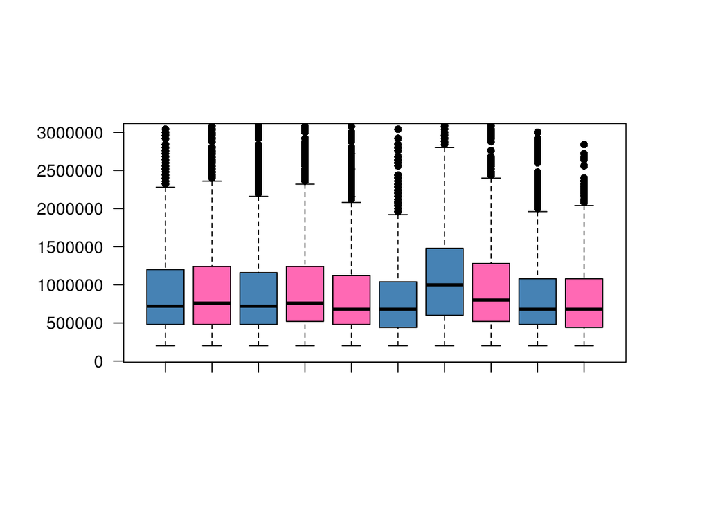

```r
setwd('/lustre/user/liclab/pengt/projects/lung/hic/caICB/TAD')
N5534 <- read.table('5534N.tad.bed')[,4]
T5534 <- read.table('5534T_10_6.tad.bed')[,4]
N6405 <- read.table('6405N.tad.bed')[,4]
T6405 <- read.table('6405T.tad.bed')[,4]
A549 <- read.table('a549_10_5.tad.bed')[,4]
Normal <- read.table('normal.tad.bed')[,4]
PrEC <- read.table('PrEC.tad.bed')[,4]
PC3 <- read.table('PC3.tad.bed')[,4]
MCF10A <- read.table('MCF10A.tad.bed')[,4]
MCF7 <- read.table('MCF7.tad.bed')[,4]
par(oma=c(2,2,2,2))
boxplot(N5534,T5534,N6405,T6405,A549,Normal,PrEC,PC3,MCF10A,MCF7,main="",ylim=c(100000,3000000),col = c("steelblue","hotpink","steelblue","hotpink","hotpink","steelblue",
                                                                          "steelblue", "hotpink","steelblue","hotpink"),las = 2,pch=16)
```